# Connaissances et Dépistage du VIH en République Démocratique du Congo

Ntumba Nkengesha Nella

26-09-2025

# 1. Introduction

Ce rapport analyse les connaissances, attitudes et comportements de dépistage du VIH chez les femmes en République Démocratique du Congo à partir du fichier IR (CDIR61FL.DTA). L’objectif est de fournir un aperçu clair des indicateurs clés liés au VIH.

# 2. Données démographiques

Les données sont importées depuis le fichier CDIR61FL.DTA grâce à la fonction read_dta(). Seules les variables d’intérêt sont sélectionnées : caseid, v001, v002, v003, v012, v013, v024, v025, v106, v190, v130, v131, v751, v754cp, v756, v774b, v774c, v779, v780, v825, v781, v783, v826, v827 et v005.

Enfin, la variable weight est recalculée en divisant sa valeur par 1 000 000 afin d’obtenir un poids normalisé utilisable pour les analyses statistiques pondérées.

## 2.1 Objectif Général

Évaluer les connaissances et les attitudes des femmes en République Démocratique du Congo concernant le dépistage du VIH afin d’identifier les facteurs influençant leur recours au test.

## 2.2 Objectif spécifiques

- 1. Determiner les facteurs qui influencent les connaissances et les attitudes au dépistage au VIH chez les femmes en RDC
- 2. Determier le niveau d’education chez les femmes qui influence les connaissances et les attitudes au dépistage au VIH chez les femmes en RDC

## 2.3 Distribution par âge

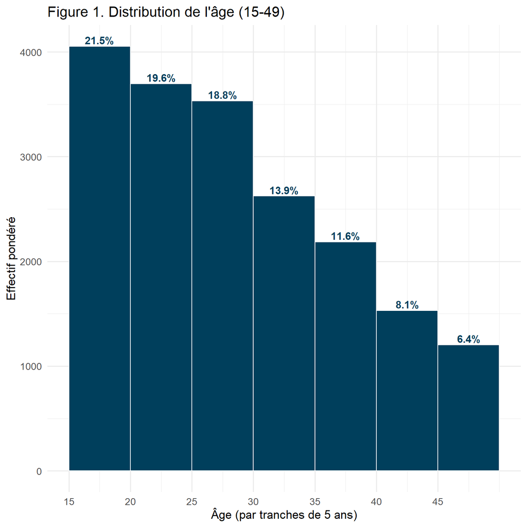

## 2.4 Éducation par lieu de résidence

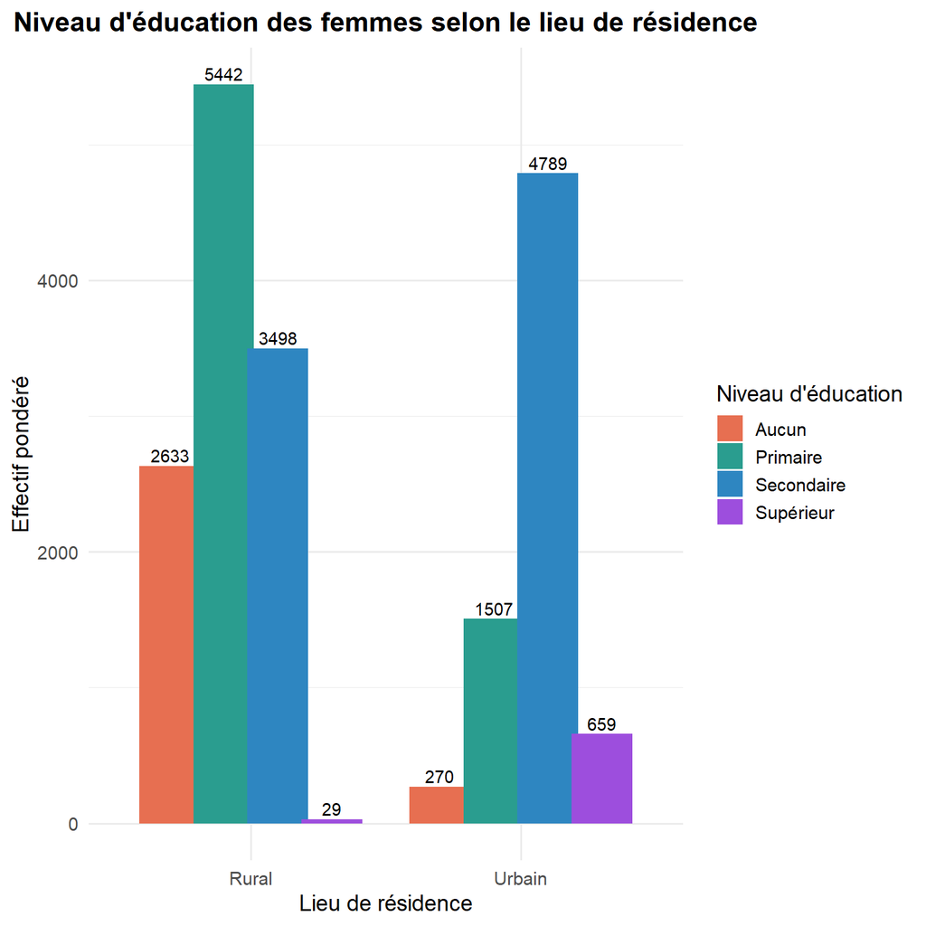

Figure 2. Niveau d’éducation des femmes par lieu de résidence

La Figure 2 met clairement en évidence la différence entre les milieux de résidence. Les femmes urbaines présentent une proportion plus importante d’éducation secondaire et supérieure, tandis que les femmes rurales sont majoritairement regroupées dans les catégories primaire ou sans éducation, soulignant un écart marqué dans l’accès à l’éducation.

# 3. Connaissances VIH

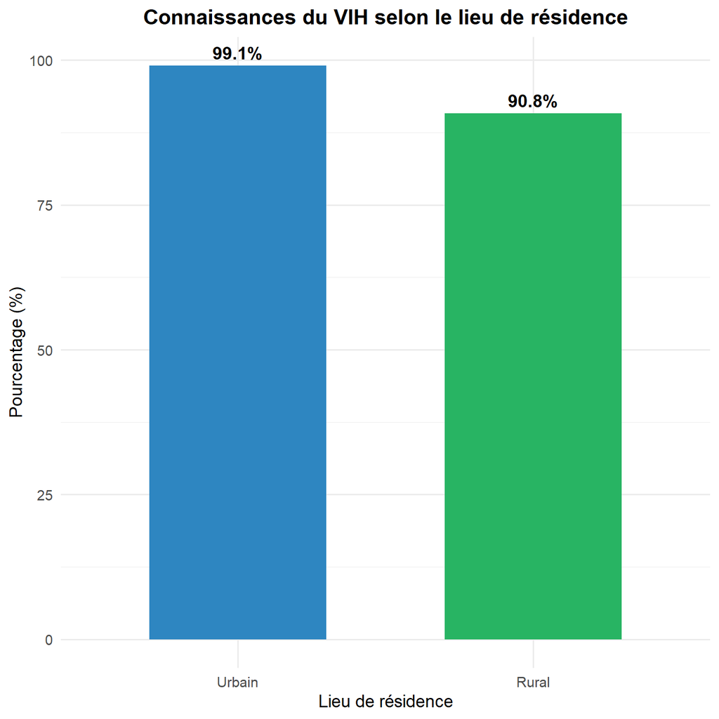

Le graphique met en évidence les connaissances du VIH selon le lieu de résidence : - 1. Urbain : 99,1 % des femmes déclarent avoir des connaissances sur le VIH. - 2. Rural : 90,8 % des femmes possèdent également des connaissances, mais à un niveau légèrement inférieur.

Globalement, le niveau de connaissance du VIH est très élevé aussi bien en milieu urbain qu’en milieu rural. Toutefois, un écart existe en faveur des zones urbaines (≈ 8 points de différence).

# 4. Attitudes

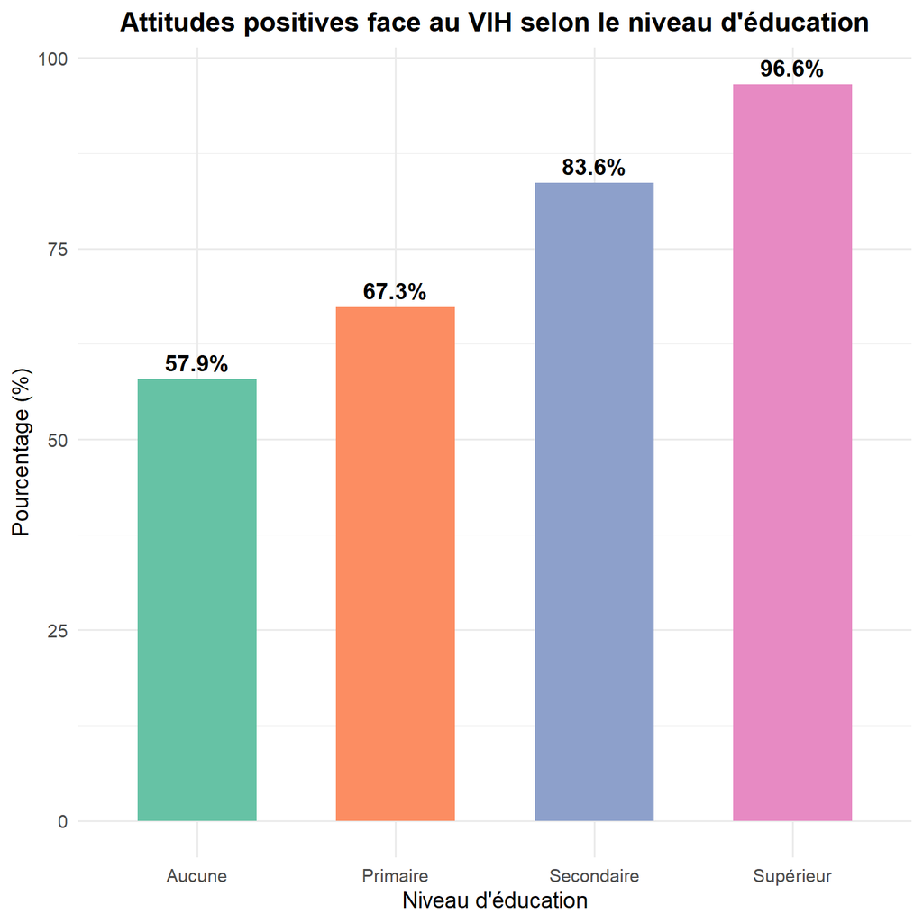

- 1. Sans instruction : 57,9 %
- 2. Primaire : 67,3 %
- 3. Secondaire : 83,6 %
- 4. Supérieur : 96,6 %

# 5. Dépistage VIH

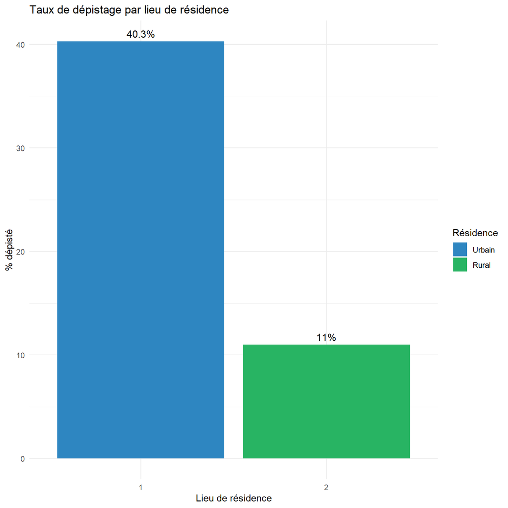

Le graphique montre la répartition du dépistage du VIH selon le lieu de résidence : - Milieu urbain : 40,3 % des femmes ont déjà effectué un test de dépistage. - Milieu rural : seulement 11 % des femmes se sont fait dépister.

Les femmes vivant en zone urbaine présentent un taux de dépistage nettement plus élevé que celles des zones rurales. Cette disparité peut être expliquée par : - un meilleur accès aux centres de santé et aux services de dépistage en ville ; - une plus grande sensibilisation et disponibilité de l’information en milieu urbain ; - des barrières culturelles, financières ou logistiques plus fortes en milieu rural.

# 6. Conclusion

Ce rapport fournit des indicateurs clés sur les connaissances, les attitudes et le dépistage du VIH chez les femmes en République Démocratique du Congo (RDC). Il décrit l’état des connaissances et du dépistage du VIH dans le pays, ainsi que les principaux facteurs qui les influencent.

Ainsi, le niveau d’éducation et le lieu de résidence apparaissent comme des déterminants majeurs des connaissances liées au dépistage du VIH en RDC.